# DI722 PA2

Şeyma Alan - 2380053

## Part 0

- I have downloaded the partitioned NY taxi dataset. Since my computer could not run all of the tables at the same time, I completed this assignment with just 1 partition. Note: We can use all partitioned datasets and merge them in a proper way so that we can reach the whole dataset.
- I have uploaded our dataset to postgres using *DBeaver* to my table *ny_taxi_04_06*.

```python
import pandas as pd
```

```python
df_0 = pd.read_csv('ny_taxi_04_06.csv')
```

```python
df_0.head()
```

|  | Unnamed: 0 | VendorID | tpep_pickup_datetime | tpep_dropoff_datetime | passenger_count | trip_distance | pickup_longitude | pickup_latitude | RateCodeID | store_and_fwd_flag | dropoff_longitude | dropoff_latitude | payment_type | fare_amount | extra | mta_tax | tip_amount | tolls_amount | total_amount |
| --- | --- | --- | --- | --- | --- | --- | --- | --- | --- | --- | --- | --- | --- | --- | --- | --- | --- | --- | --- |
| 0 | 45054475 | 1 | 2015-04-08 19:05:51 | 2015-04-08 19:22:25 | 1 | 0.90 | -73.988518 | 40.769928 | 1 | N | -73.985252 | 40.760094 | 1 | 11.0 | 1.0 | 0.5 | 3.2 | 0.0 | 16.0 |
| 1 | 56492535 | 2 | 2015-05-21 20:03:20 | 2015-05-21 20:16:50 | 1 | 1.19 | -73.981865 | 40.766624 | 1 | N | -73.978447 | 40.754414 | 1 | 9.5 | 0.5 | 0.5 | 2.7 | 0.0 | 13.5 |
| 2 | 56322720 | 1 | 2015-05-06 12:48:09 | 2015-05-06 13:09:01 | 1 | 1.20 | -74.005272 | 40.740742 | 1 | Y | -73.996620 | 40.753300 | 2 | 13.0 | 0.0 | 0.5 | 0.0 | 0.0 | 13.8 |
| 3 | 66071630 | 1 | 2015-06-04 08:04:31 | 2015-06-04 08:15:18 | 1 | 0.90 | -73.989334 | 40.758530 | 1 | N | -73.973083 | 40.753605 | 2 | 8.0 | 0.0 | 0.5 | 0.0 | 0.0 | 8.8 |
| 4 | 55608299 | 2 | 2015-05-05 16:48:45 | 2015-05-05 17:03:52 | 5 | 2.47 | -73.960724 | 40.770634 | 1 | N | -73.984238 | 40.770748 | 2 | 12.0 | 1.0 | 0.5 | 0.0 | 0.0 | 13.8 |

- However, in our dataset 'id' column name was "Null" so I filled column name as "id".

```python
df_0 = df_0.rename(columns={'Unnamed: 0': 'id'})
```

```python
df_0.head()
```

|  | id | VendorID | tpep_pickup_datetime | tpep_dropoff_datetime | passenger_count | trip_distance | pickup_longitude | pickup_latitude | RateCodeID | store_and_fwd_flag | dropoff_longitude | dropoff_latitude | payment_type | fare_amount | extra | mta_tax | tip_amount | tolls_amount | total_amount |
| --- | --- | --- | --- | --- | --- | --- | --- | --- | --- | --- | --- | --- | --- | --- | --- | --- | --- | --- | --- |
| 0 | 45054475 | 1 | 2015-04-08 19:05:51 | 2015-04-08 19:22:25 | 1 | 0.90 | -73.988518 | 40.769928 | 1 | N | -73.985252 | 40.760094 | 1 | 11.0 | 1.0 | 0.5 | 3.2 | 0.0 | 16.0 |
| 1 | 56492535 | 2 | 2015-05-21 20:03:20 | 2015-05-21 20:16:50 | 1 | 1.19 | -73.981865 | 40.766624 | 1 | N | -73.978447 | 40.754414 | 1 | 9.5 | 0.5 | 0.5 | 2.7 | 0.0 | 13.5 |
| 2 | 56322720 | 1 | 2015-05-06 12:48:09 | 2015-05-06 13:09:01 | 1 | 1.20 | -74.005272 | 40.740742 | 1 | Y | -73.996620 | 40.753300 | 2 | 13.0 | 0.0 | 0.5 | 0.0 | 0.0 | 13.8 |
| 3 | 66071630 | 1 | 2015-06-04 08:04:31 | 2015-06-04 08:15:18 | 1 | 0.90 | -73.989334 | 40.758530 | 1 | N | -73.973083 | 40.753605 | 2 | 8.0 | 0.0 | 0.5 | 0.0 | 0.0 | 8.8 |
| 4 | 55608299 | 2 | 2015-05-05 16:48:45 | 2015-05-05 17:03:52 | 5 | 2.47 | -73.960724 | 40.770634 | 1 | N | -73.984238 | 40.770748 | 2 | 12.0 | 1.0 | 0.5 | 0.0 | 0.0 | 13.8 |

```python
df_0.to_csv("out.csv")
```

- Then I imported necessary libraries into Python.

```python
import psycopg2
import matplotlib.pyplot as plt
```

- I connected the database to my python script using psycopg2

```python
conn = psycopg2.connect("dbname=di722 user=postgres password=password")
```

```python
cur = conn.cursor()
```

```python
cur.execute("SELECT * FROM yellow_geom LIMIT 5")
```

```python
# just checking :)

for record in cur:
    print(record)
    print("\n")
```

```
(45054475, '1', datetime.datetime(2015, 4, 8, 19, 5, 51), datetime.datetime(2015, 4, 8, 19, 22, 25), 1, 0.9, -73.98851776123048, 40.769927978515625, '1 ', 'N', -73.9852523803711, 40.76009368896485, '1', 11.0, 1.0, 0.5, 3.2, 0.0, 16.0, '0101000020E6100000010000E0437F52C0000000008D624440', '0101000020…


(56492535, '2', datetime.datetime(2015, 5, 21, 20, 3, 20), datetime.datetime(2015, 5, 21, 20, 16, 50), 1, 1.19, -73.98186492919923, 40.7666244506836, '1 ', 'N', -73.97844696044923, 40.75441360473633, '1', 9.5, 0.5, 0.5, 2.7, 0.0, 13.5, '0101000020E6100000010000E0D67E52C0010000C020624440', '010100002…


(56322720, '1', datetime.datetime(2015, 5, 6, 12, 48, 9), datetime.datetime(2015, 5, 6, 13, 9, 1), 1, 1.2, -74.0052719116211, 40.74074172973633, '1 ', 'Y', -73.99662017822266, 40.753299713134766, '2', 13.0, 0.0, 0.5, 0.0, 0.0, 13.8, '0101000020E610000000000060568052C0000000A0D05E4440', '0101000020E6…


(66071630, '1', datetime.datetime(2015, 6, 4, 8, 4, 31), datetime.datetime(2015, 6, 4, 8, 15, 18), 1, 0.9, -73.98933410644531, 40.75852966308594, '1 ', 'N', -73.97308349609375, 40.753604888916016, '2', 8.0, 0.0, 0.5, 0.0, 0.0, 8.8, '0101000020E610000000000040517F52C00000008017614440', '0101000020E61…


(55608299, '2', datetime.datetime(2015, 5, 5, 16, 48, 45), datetime.datetime(2015, 5, 5, 17, 3, 52), 5, 2.47, -73.96072387695312, 40.770633697509766, '1 ', 'N', -73.98423767089844, 40.77074813842773, '2', 12.0, 1.0, 0.5, 0.0, 0.0, 13.8, '0101000020E6100000000000807C7D52C000000020A4624440', '01010000…
```

Insert all of the dataset into a pandas dataframe so that we can work easily.

```python
df = pd.read_sql_query("SELECT * FROM yellow_geom",conn)
```

```python
df.head()
```

|  | id | vendorid | tpep_pickup_datetime | tpep_dropoff_datetime | passenger_count | trip_distance | pickup_longitude | pickup_latitude | ratecodeid | store_and_fwd_flag | ... | dropoff_latitude | payment_type | fare_amount | extra | mta_tax | tip_amount | tolls_amount | total_amount | l_pickup | l_dropoff |
| --- | --- | --- | --- | --- | --- | --- | --- | --- | --- | --- | --- | --- | --- | --- | --- | --- | --- | --- | --- | --- | --- |
| 0 | 45054475 | 1 | 2015-04-08 19:05:51 | 2015-04-08 19:22:25 | 1 | 0.90 | -73.988518 | 40.769928 | 1 | N | ... | 40.760094 | 1 | 11.0 | 1.0 | 0.5 | 3.2 | 0.0 | 16.0 | 0101000020E6100000010000E0437F52C0000000008D62... | 0101000020E6100000000000600E7F52C0010000C04A61... |
| 1 | 56492535 | 2 | 2015-05-21 20:03:20 | 2015-05-21 20:16:50 | 1 | 1.19 | -73.981865 | 40.766624 | 1 | N | ... | 40.754414 | 1 | 9.5 | 0.5 | 0.5 | 2.7 | 0.0 | 13.5 | 0101000020E6100000010000E0D67E52C0010000C02062... | 0101000020E6100000010000E09E7E52C0000000A09060... |
| 2 | 56322720 | 1 | 2015-05-06 12:48:09 | 2015-05-06 13:09:01 | 1 | 1.20 | -74.005272 | 40.740742 | 1 | Y | ... | 40.753300 | 2 | 13.0 | 0.0 | 0.5 | 0.0 | 0.0 | 13.8 | 0101000020E610000000000060568052C0000000A0D05E... | 0101000020E6100000000000A0C87F52C0000000206C60... |
| 3 | 66071630 | 1 | 2015-06-04 08:04:31 | 2015-06-04 08:15:18 | 1 | 0.90 | -73.989334 | 40.758530 | 1 | N | ... | 40.753605 | 2 | 8.0 | 0.0 | 0.5 | 0.0 | 0.0 | 8.8 | 0101000020E610000000000040517F52C0000000801761... | 0101000020E610000000000000477E52C0000000207660... |
| 4 | 55608299 | 2 | 2015-05-05 16:48:45 | 2015-05-05 17:03:52 | 5 | 2.47 | -73.960724 | 40.770634 | 1 | N | ... | 40.770748 | 2 | 12.0 | 1.0 | 0.5 | 0.0 | 0.0 | 13.8 | 0101000020E6100000000000807C7D52C000000020A462... | 0101000020E6100000000000C0FD7E52C0FFFFFFDFA762... |

5 rows × 21 columns

```python
df.info()
```

```
<class 'pandas.core.frame.DataFrame'>
RangeIndex: 1927596 entries, 0 to 1927595
Data columns (total 21 columns):
 #   Column                 Dtype
---  ------                 -----
 0   id                     int64
 1   vendorid               object
 2   tpep_pickup_datetime   datetime64[ns]
 3   tpep_dropoff_datetime  datetime64[ns]
 4   passenger_count        int64
 5   trip_distance          float64
 6   pickup_longitude       float64
 7   pickup_latitude        float64
 8   ratecodeid             object
 9   store_and_fwd_flag     object
 10  dropoff_longitude      float64
 11  dropoff_latitude       float64
 12  payment_type           object
 13  fare_amount            float64
 14  extra                  float64
 15  mta_tax                float64
 16  tip_amount             float64
 17  tolls_amount           float64
 18  total_amount           float64
 19  l_pickup               object
 20  l_dropoff              object
dtypes: datetime64[ns](2), float64(11), int64(2), object(6)
memory usage: 308.8+ MB
```

## Part 1

- Firstly, take the user input.

```python
from datetime import datetime
input_date = input("Please type a date in format YYYY-MM-DD (Month can be only 04,05,06): ")
input_date = datetime.strptime(input_date, '%Y-%m-%d').date()
input_resolution = input("Please enter the resolution you want in minutes : ")
input_resolution = int(input_resolution)
```

```
Please type a date in format YYYY-MM-DD (Month can be only 04,05,06): 2015-04-08
Please enter the resolution you want in minutes : 30
```

- Then, we should resample our time series.

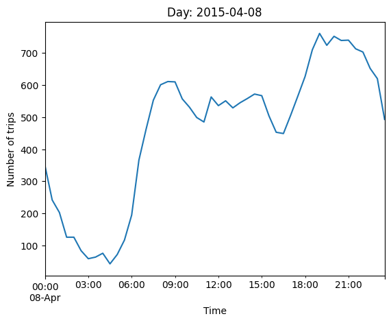

```python
# Convert tpep_pickup_datetime to datetime object

df['tpep_pickup_datetime'] = pd.to_datetime(df['tpep_pickup_datetime'])

# Take the rows that contain user input date
new = df[df['tpep_pickup_datetime'].dt.date == input_date]

# Resample the data with user input resolution
new = new.resample(str(input_resolution)+'min', on='tpep_pickup_datetime')['tpep_pickup_datetime'].size()

# Plot the resampled data
new.plot(title = "Day: " + str(input_date), xlabel = "Time", ylabel="Number of trips")
```

## Part 2: Origin-Destination Analysis

- Firstly take taxi zones table from the database

```python
df_zones = pd.read_sql_query("SELECT * FROM taxi_zones",conn)
```

```python
df_zones.head()
```

|  | gid | borough | location_i | objectid | shape_area | shape_leng | zone | geom |
| --- | --- | --- | --- | --- | --- | --- | --- | --- |
| 0 | 1 | EWR | 1.0 | 1.0 | 0.000782 | 0.116357 | Newark Airport | 0106000020E610000001000000010300000001000000E8... |
| 1 | 2 | Queens | 2.0 | 2.0 | 0.004866 | 0.433470 | Jamaica Bay | 0106000020E61000002100000001030000000100000071... |
| 2 | 3 | Bronx | 3.0 | 3.0 | 0.000314 | 0.084341 | Allerton/Pelham Gardens | 0106000020E61000000100000001030000000100000079... |
| 3 | 4 | Manhattan | 4.0 | 4.0 | 0.000112 | 0.043567 | Alphabet City | 0106000020E61000000100000001030000000100000058... |
| 4 | 5 | Staten Island | 5.0 | 5.0 | 0.000498 | 0.092146 | Arden Heights | 0106000020E610000001000000010300000001000000AA... |

- Then we should find zones of the pickup and dropoff locations. Following SQL query finds the zones corresponding to pickup and dropoff point information.

```python
df_joined_zones = pd.read_sql_query("SELECT  t.id,  t.tpep_pickup_datetime,  t.tpep_dropoff_datetime,  z.location_i AS pickup_location_id,  z2.location_i AS dropoff_location_id FROM  yellow_geom t  JOIN taxi_zones z ON ST_Contains(z.geom, t.l_pickup)  JOIN taxi_zones z2 ON ST_Contains(z2.geom, t.l_dropoff)", conn)
df_joined_zones.head()
```

|  | id | tpep_pickup_datetime | tpep_dropoff_datetime | pickup_location_id | dropoff_location_id |
| --- | --- | --- | --- | --- | --- |
| 0 | 45054475 | 2015-04-08 19:05:51 | 2015-04-08 19:22:25 | 50.0 | 230.0 |
| 1 | 56492535 | 2015-05-21 20:03:20 | 2015-05-21 20:16:50 | 163.0 | 161.0 |
| 2 | 56322720 | 2015-05-06 12:48:09 | 2015-05-06 13:09:01 | 158.0 | 68.0 |
| 3 | 66071630 | 2015-06-04 08:04:31 | 2015-06-04 08:15:18 | 48.0 | 162.0 |
| 4 | 55608299 | 2015-05-05 16:48:45 | 2015-05-05 17:03:52 | 237.0 | 142.0 |

- Take the user input.

```python
input_doi = input("Please type the date of analysis in format YYYY-MM-DD (Month can be only 04,05,06): ")
input_interval = input("Please enter the analysis interval you want in minutes : ")
input_interval = str(input_interval) + "min"
input_k = input("Please enter the number of trips occured the most you want to see: ")
```

```
Please type the date of analysis in format YYYY-MM-DD (Month can be only 04,05,06): 2015-04-08
Please enter the analysis interval you want in minutes : 120
Please enter the number of trips occured the most you want to see: 3
```

- Since the pandas generate warning after using append. I suspended warnings.

```python
import warnings
# Suppress FutureWarnings from pandas
warnings.filterwarnings('ignore', category=FutureWarning)
```

```python
# Convert the pickup and dropoff columns to datetime objects

df_joined_zones["tpep_pickup_datetime"] = pd.to_datetime(df_joined_zones["tpep_pickup_datetime"])
df_joined_zones["tpep_dropoff_datetime"] = pd.to_datetime(df_joined_zones["tpep_dropoff_datetime"])


# Create a datetime range with the user input interval

start_time = pd.to_datetime(input_doi)
end_time = start_time + pd.Timedelta(days=1)
time_range = pd.date_range(start_time, end_time, freq=input_interval)


results_df = pd.DataFrame(columns=["start_time", "end_time", "pickup_location_id", "dropoff_location_id", "count"])

for i in range(len(time_range)-1):

    start_time = time_range[i]
    end_time = time_range[i+1]

    # Take rows that fall into our calculated time interval

    interval_df = df_joined_zones[(df_joined_zones["tpep_pickup_datetime"] >= start_time) & (df_joined_zones["tpep_pickup_datetime"] < end_time)]

    # Group by pickup and dropoff locations and count the number of trips

    count_df = interval_df.groupby(["pickup_location_id", "dropoff_location_id"]).size().reset_index(name="count")

    # Take the input k counts and append them to resulting dataframe

    top_counts = count_df.nlargest(int(input_k), "count")
    for i, row in top_counts.iterrows():
        results_df = results_df.append({"start_time": start_time, "end_time": end_time, "pickup_location_id": row["pickup_location_id"], "dropoff_location_id": row["dropoff_location_id"], "count": row["count"]}, ignore_index=True)



results_df.head()
```

|  | start_time | end_time | pickup_location_id | dropoff_location_id | count |
| --- | --- | --- | --- | --- | --- |
| 0 | 2015-04-08 00:00:00 | 2015-04-08 02:00:00 | 48.0 | 48.0 | 4.0 |
| 1 | 2015-04-08 00:00:00 | 2015-04-08 02:00:00 | 79.0 | 170.0 | 4.0 |
| 2 | 2015-04-08 00:00:00 | 2015-04-08 02:00:00 | 107.0 | 36.0 | 4.0 |
| 3 | 2015-04-08 02:00:00 | 2015-04-08 04:00:00 | 79.0 | 97.0 | 3.0 |
| 4 | 2015-04-08 02:00:00 | 2015-04-08 04:00:00 | 79.0 | 255.0 | 3.0 |

## Part 3

- You can import whole dataset into QGIS and filter by querying to take the desired rows. However, this ends up with long processing times and QGIS might stop responding depending on your computer.
- Therefore, I pick a set that I want to visualize on QGIS.

```python
part3_df = df_joined_zones[(df_joined_zones['tpep_pickup_datetime'] >= "2015-04-08 00:00:00")]
part3_df = part3_df[part3_df['tpep_pickup_datetime'] <= "2015-04-08 02:00:00"]
part3_df = part3_df[part3_df['pickup_location_id'] == 48]
part3_df = part3_df[part3_df['dropoff_location_id'] == 48]
part3_df
```

|  | id | tpep_pickup_datetime | tpep_dropoff_datetime | pickup_location_id | dropoff_location_id |
| --- | --- | --- | --- | --- | --- |
| 296345 | 44440987 | 2015-04-08 00:12:43 | 2015-04-08 00:14:24 | 48.0 | 48.0 |
| 537973 | 44443802 | 2015-04-08 00:27:14 | 2015-04-08 00:27:36 | 48.0 | 48.0 |
| 1444450 | 44460541 | 2015-04-08 01:07:10 | 2015-04-08 01:10:06 | 48.0 | 48.0 |
| 1508833 | 44462229 | 2015-04-08 01:20:36 | 2015-04-08 01:25:03 | 48.0 | 48.0 |

- It is easier for me to use X and Y coordinates of the pickup and dropoff locations while visualizing on QGIS.
- Therefore, I joined resulting dataframe with original dataset.

```python
part3_results_df = pd.DataFrame(columns=["id","lon_pickup","lat_pickup","lon_dropoff","lat_dropoff", "l_pickup", "l_dropoff"])

for i, row in part3_df.iterrows():
    id = row['id']
    part3_results_df = part3_results_df.append({"id": id,"lon_pickup": df.loc[df['id'] == id, 'pickup_longitude'].values[0],"lat_pickup":df.loc[df['id'] == id, 'pickup_latitude'].values[0] ,"lon_dropoff":df.loc[df['id'] == id, 'dropoff_longitude'].values[0] ,"lat_dropoff": df.loc[df['id'] == id, 'dropoff_latitude'].values[0], "l_pickup" : df.loc[df['id'] == id, 'l_pickup'].values[0], "l_dropoff": df.loc[df['id'] == id, 'l_dropoff'].values[0] }, ignore_index=True )
```

- Save the resulting dataframe into a csv file to use it in QGIS.

```python
part3_results_df.to_csv("part3_xy.csv")
```

- Here is the result:

[figure not shown]

- Since one of the rows contain same pickup and dropoff location. We see 3 pickup points instead of 4. One point falls behind the red dropoff_points.

```python
part3_results_df
```

|  | id | lon_pickup | lat_pickup | lon_dropoff | lat_dropoff | l_pickup | l_dropoff |
| --- | --- | --- | --- | --- | --- | --- | --- |
| 0 | 44440987 | -73.986450 | 40.767014 | -73.990578 | 40.761459 | 0101000020E610000000000000227F52C0000000802D62... | 0101000020E6100000000000A0657F52C0000000807761... |
| 1 | 44443802 | -73.993340 | 40.757172 | -73.993340 | 40.757172 | 0101000020E6100000000000E0927F52C000000000EB60... | 0101000020E6100000000000E0927F52C000000000EB60... |
| 2 | 44460541 | -73.989868 | 40.757130 | -73.989914 | 40.764805 | 0101000020E6100000000000005A7F52C0FFFFFF9FE960... | 0101000020E6100000FFFFFFBF5A7F52C000000020E561... |
| 3 | 44462229 | -73.984909 | 40.768188 | -73.988312 | 40.761570 | 0101000020E6100000000000C0087F52C0000000005462... | 0101000020E6100000FFFFFF7F407F52C0000000207B61... |

## Part 4

#### Project description:

ChatGPT is the most popular tool in the software world for several months. It is a large language model developed by OpenAI, based on the GPT (Generative Pre-trained Transformer) architecture. It is capable of generating human-like text in response to a given prompt, allowing it to engage in conversation with users. ChatGPT was trained on a massive amount of text data, allowing it to learn patterns and relationships in language and generate coherent and contextually appropriate responses.

OpenAI offers its API to developers. With the OpenAI API, developers can integrate the latest natural language processing (NLP), machine learning, and deep learning algorithms into their applications, making them smarter and more sophisticated.

This project will take user prompts about NYC Taxis and generate useful outputs (i.e. trip duration estimastion, trip price calculation, route recommendation etc.) based on prompts using OpenAI API and NYC Taxi Dataset. Also the project might visualize its outputs and integrate with QGIS.

#### Project Purpose & Goals:

**Project Purpose:**

The purpose of this project is to leverage the NYC Taxi dataset to create a tool that can provide useful information to taxi riders and users in New York City. By using machine learning models and natural language processing, the project aims to generate accurate and contextually appropriate responses to user prompts about taxi trips. Additionally, by visualizing this information on a map using QGIS, the project seeks to provide a more engaging and intuitive user experience.

**Project Goals:**

- To develop a tool that uses the OpenAI API to generate text-based outputs in response to user prompts about NYC taxi trips.
- To create machine learning models based on the NYC Taxi dataset that can estimate trip costs, predict taxi demand, and recommend alternate pickup locations or routes.
- To integrate these models with the OpenAI API to provide accurate and contextually appropriate responses to user prompts.
- To visualize the generated outputs on a QGIS map, allowing users to easily understand and interact with the information.

#### Project Features:

This feature list might grow or shrink depending on project deadline and OpenAI API limits.

- Generate descriptions of taxi routes: Generate descriptions of taxi routes based on the pickup and dropoff locations in the NYC Taxi Dataset using OpenAI API. For example, the generated text could describe landmarks, historical sites, or notable buildings along the route.
- Estimate trip costs: Use the OpenAI API to generate estimates of taxi trip costs based on pickup and dropoff locations in the NYC taxi dataset. These estimates could be displayed on a QGIS map.
- Predict taxi demand: Use the NYC Taxi Dataset to train a machine learning model to predict taxi demand in different parts of the city. You could then use the OpenAI API to generate recommendations for passengers based on the predicted demand, such as suggesting alternate pickup locations or routes to avoid traffic.

#### Project Roadmap:

1. **Data Preparation**
   - Clean the NYC Taxi dataset by removing any duplicates, missing values, or inconsistent data.
   - Preprocess the dataset by converting it to a format that can be used with the OpenAI API.
2. **Register for the OpenAI API and obtain an API key.**
   - Integrate the OpenAI API into the project by installing the OpenAI Python library and setting up the API credentials.
   - Create a Python script to interact with the OpenAI API, allowing it to generate text-based outputs based on user prompts.
   - Note: OpenAI gives only 3 months free usage.
3. **Feature Development**
   - Develop features to estimate trip costs, predict taxi demand, and recommend alternate pickup locations or routes.
   - Train machine learning models using the NYC Taxi dataset to predict trip costs, taxi demand, and other relevant metrics.
   - Use the OpenAI API to generate text-based outputs based on these models, allowing the user to make informed decisions about their taxi trips.